# coursera_practical_machine_learning_final

Bruce Walthers

10/12/2016

## Data Preparation

When I loaded the dataset into R, I needed to change a few column classes to “numeric”" because they came in as “character.” The primary reason for this was several of the columns had a divide by zero error, “#DIV/0!”, which forced the column to auto-convert to character instead of numeric. I simply replaced those divide by zero values with an actual zero and then converted the column to numeric. I also looked for near zero variance variables and removed those from the model.

## Partitioning Datasets

I split the train dataset into 2 datasets, training and testing, using the createDataPartition function in caret. I also made the decision at this point to remove any variables where the NA percentage for that variable was above 95%. My thought process was there would not be much signal there and if I turned out to be wrong, I could add those back. I never added them back.

```r
dim(training)
```

```
## [1] 13737   120
```

```r
dim(testing)
```

```
## [1] 5885  120
```

```r
dim(validation)
```

```
## [1]  20 120
```

## Building of my model

I decided to build a GBM model. I used 10-fold cross validation with 3 repeats in the model. I trained the model using the caret package. I printed out the variable importance for the model and I have reproduced the plot below. I could have choosen to remove some of the lower importance variables for a more parsimonious model but decided to keep them in.

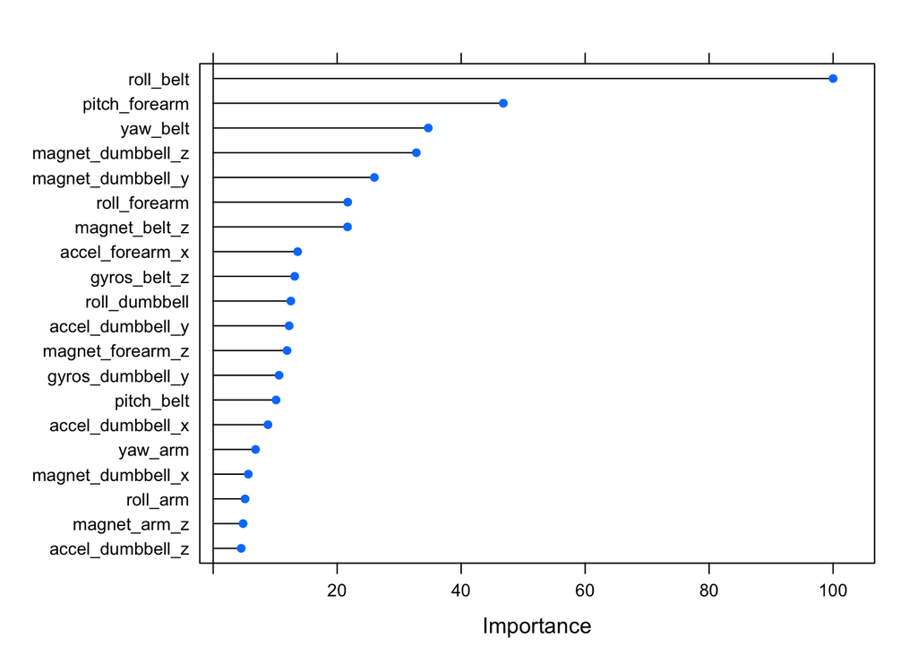

## Predict testing set and check performance

```
##           Reference
## Prediction    A    B    C    D    E
##          A 1652   36    0    0    2
##          B   16 1071   39    3   16
##          C    3   30  970   34    9
##          D    2    1   15  927   13
##          E    1    1    2    0 1042
```

```
##  Accuracy
## 0.9621071
```

## Predicting the validation set

Next, I predicted the validation set and entered the answers into the class quiz. I received a 20/20 so all my predictions were accurate which seems to be inline or slightly better then what I had expected the accuracy to be.